# Retail Superstore

# Which state are top and bottom in terms of sales?

```python
df_state[df_state['Sales']==max(df_state['Sales'])]
```

|  | State | Sales | Profit |
| --- | --- | --- | --- |
| 3 | California | 457687.6315 | 76381.3871 |

```python
df_state[df_state['Sales']==min(df_state['Sales'])]
```

|  | State | Sales | Profit |
| --- | --- | --- | --- |
| 32 | North Dakota | 919.91 | 230.1497 |

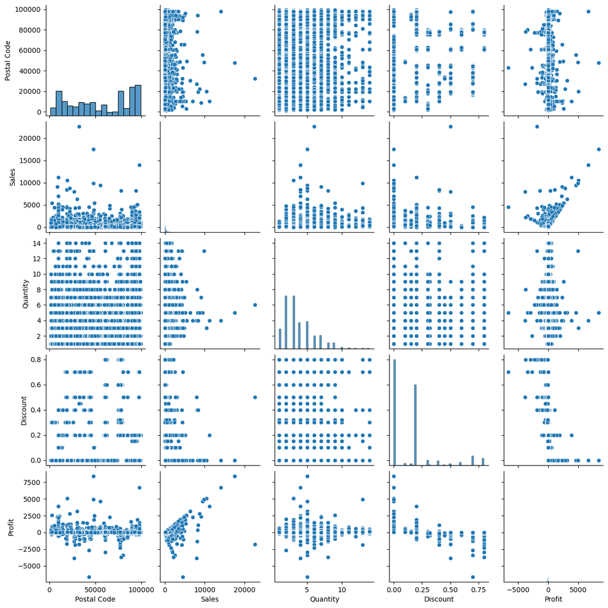

```python
plt.figure(figsize=(25,20))
sns.pairplot(df)
plt.show()
```

# RECOMMENDATIONS

2.We should either minimize selling or reduce discount on Furniture category as it is providing least profit especially Tables sub-category which is incurring huge losses.

3.The sales of Fasteners,Envelops,Labels and Art are extremely low, to improve this condition more discounted offers should be provided for a short interval of time to give boost to the sales.

4.The discount is observed to have negatively impacting sales somehow that is a major problem, planning for amount of discount on different products should be restructured such as the in demand products have a moderate discount while heavy discount offers should be provided for less sold products.